# Modeling Swire Coca Cola

#### 5.2.2. Costs by Maintenance Type and Machine Age

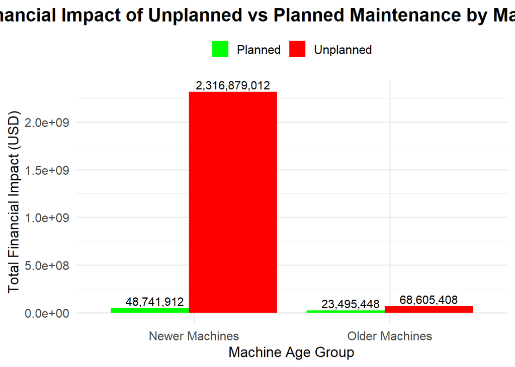

```r
# Define dynamic cost variables
cost_per_minute <- 10
downtime_cost_multiplier <- 20

# Calculate financial impact by maintenance type and machine age
data <- data %>%
  mutate(
    FINANCIAL_IMPACT = ifelse(
      MAINTENANCE_ACTIVITY_TYPE == "Unplanned",
      ACTUAL_WORK_IN_MINUTES * downtime_cost_multiplier,
      ACTUAL_WORK_IN_MINUTES * cost_per_minute
    ),
    AGE_GROUP = ifelse(MACHINE_AGE > median(data$MACHINE_AGE, na.rm = TRUE), "Older Machines", "Newer Machines")
  )

# Summarize financial impact by maintenance type and machine age
financial_impact_age <- data %>%
  group_by(MAINTENANCE_ACTIVITY_TYPE, AGE_GROUP) %>%
  summarise(total_impact = sum(FINANCIAL_IMPACT, na.rm = TRUE), .groups = "drop")

# Plot financial impact of unplanned vs planned maintenance by age group
ggplot(financial_impact_age, aes(x = AGE_GROUP, y = total_impact, fill = MAINTENANCE_ACTIVITY_TYPE)) +
  geom_bar(stat = "identity", position = position_dodge(width = 0.8)) + # Dodge for spacing
  scale_fill_manual(values = c("Unplanned" = "red", "Planned" = "green")) +
  labs(
    title = "Financial Impact of Unplanned vs Planned Maintenance by Machine Age",
    x = "Machine Age Group",
    y = "Total Financial Impact (USD)"
  ) +
  theme_minimal(base_size = 15) +
  theme(
    plot.title = element_text(hjust = 0.5, size = 18, face = "bold"),
    axis.title.x = element_text(size = 14),
    axis.title.y = element_text(size = 14),
    legend.title = element_blank(),
    legend.position = "top"
  ) +
  geom_text(aes(label = scales::comma(total_impact, accuracy = 1)), # Add labels with commas for readability
            position = position_dodge(width = 0.8), vjust = -0.3, size = 4, color = "black") # Adjust label position
```

**Key Insights:**

### 5.3. Business validation of models

#### 5.3.1. How can these models optimize Swire Coca-Cola’s maintenance processes?

The machine failure prediction models developed in this analysis provide several key insights that can optimize Swire Coca-Cola’s maintenance processes:

- **Predictive Maintenance:** By identifying potential failures before they occur, Swire Coca-Cola can implement predictive maintenance strategies, reducing unplanned downtime and maintenance costs.
- **Targeted Interventions:** Models allow for a focused approach on high-maintenance machines, ensuring that resources are allocated efficiently. Maintenance efforts can be concentrated on machines identified as high-risk.
- **Regional Strategies:** Understanding machine performance by region can help tailor maintenance schedules and operational strategies to regional needs, optimizing labor and resources.
- **Age-Based Maintenance Strategies:** Differentiating between older and newer machines enables the development of customized maintenance plans, improving efficiency and machine lifespan.
- **Performance Monitoring:** Continuous monitoring of model predictions can facilitate ongoing assessments of machine health, helping to validate and refine maintenance strategies over time.

#### 5.3.2. Can the Model Results Solve the Business Problem?

The model results provide actionable insights that can directly address Swire Coca-Cola’s maintenance challenges. By focusing on predictive maintenance, the models can minimize unplanned downtime and improve the allocation of resources across different machine categories and regions. Furthermore, the insights gained from the age-based and regional strategies will enable Swire Coca-Cola to design maintenance schedules that are more cost-effective and aligned with specific operational needs.

The models not only help in proactively addressing machine failures but also enable continuous refinement and monitoring, ensuring that maintenance strategies remain relevant and effective over time.

## 6. Team Contribution

**Sakshi Pandey**:  
Sakshi led the overall project coordination, ensuring alignment across different components of the modeling assignment. She contributed significantly to the EDA, exploring various dimensions of the data such as machine age, maintenance types, and regional breakdowns. Additionally, she worked on interpreting the model results and incorporating them into actionable business insights, focusing on cost analysis and how predictive maintenance could optimize operational strategies for Swire Coca-Cola. Sakshi also contributed to the final report and presentation preparation, ensuring clear communication of the results to stakeholders.

**Kritika**:  
Kritika focused on data preprocessing, including cleaning the dataset, handling missing values, and ensuring that the data was ready for modeling. She was involved in the feature engineering process, where she created new features that enhanced model performance, particularly focusing on machine-related characteristics. Additionally, Kritika assisted in tuning the models to optimize accuracy and collaborated closely with Sakshi on interpreting the results for business insights.

**Anish Khairnar**:  
Anish took the lead in building and fine-tuning the predictive models. He implemented several algorithms, including Logistic Regression, Random Forest, and XGBoost, and carried out extensive model validation. He was responsible for evaluating the models’ performance through metrics such as accuracy and interpretability, helping to identify the best-performing models across different machine categories. His contribution was crucial in ensuring the robustness and reliability of the models.

**Ankur Chitnis & Sambit Pani**:  
Ankur and Sambit worked collaboratively on the modeling process, starting with detailed exploratory data analysis (EDA) to understand the data’s structure and identify key patterns. They addressed overfitting, performed feature engineering, and created dummy variables for categorical data, which laid the foundation for accurate model development. Their work ensured the models were well-calibrated and aligned with business goals. Their thorough approach ensured the models were both robust and aligned with Swire Coca-Cola’s maintenance needs.

## 9. Recommendation:

**1. Operational Strategy Recommendations for Swire Coca-Cola’s Maintenance Team**

**Audience**: Swire Coca-Cola’s leadership team and operational decision-makers.  
**Focus**: Optimizing predictive maintenance, improving efficiency, and reducing operational costs.

- **Implement Predictive Maintenance Systems**:

  *Recommendation*: Adopt predictive maintenance systems to reduce unplanned downtime and repair costs by identifying potential failures early. This proactive approach will ensure optimal machine health and minimal disruption to production schedules.
- **Cost Savings Through Tailored Maintenance Plans**:

  *Recommendation*: Develop tailored maintenance plans based on machine age and failure probability. Older machines or those identified as high-risk should receive priority maintenance to prevent costly repairs and extend their lifespan.
- **Regional Maintenance Optimization for Cost Efficiency**:

  *Recommendation*: Implement region-specific strategies by identifying areas with higher failure rates. Allocate maintenance resources based on predictive insights to reduce unnecessary costs and improve regional operational efficiency.
- **Focus on High-Risk Machines to Cut Costs**:

  *Recommendation*: Prioritize high-risk machines for proactive maintenance. By targeting machines more likely to fail, Swire Coca-Cola can minimize downtime and costly emergency repairs, optimizing both labor and material resources.
- **Continuous Cost Monitoring and Model Refinement**:

  *Recommendation*: Establish a system for continuous monitoring and model refinement. By tracking performance metrics over time and adjusting predictive models accordingly, Swire Coca-Cola can ensure sustained cost savings and operational optimization.

**2. Strategic and Investment Recommendations for Swire Coca-Cola’s Sponsors and Executives**

**Audience**: Sponsors of the project, including Swire Coca-Cola executives, external partners, and investors.  
**Focus**: Long-term strategic decisions, investments, and system scalability for predictive maintenance.

- **Invest in Data Infrastructure for Cost Optimization**:

  *Recommendation*: Invest in advanced data infrastructure, such as IoT sensors and analytics platforms, to support the predictive maintenance system. This will improve model accuracy, help identify additional cost-saving opportunities, and optimize overall machine performance.
- **Promote a Cost-Conscious, Data-Driven Maintenance Culture**:

  *Recommendation*: Encourage a culture of cost-consciousness and data-driven decision-making across maintenance teams. By integrating predictive insights into daily maintenance practices, operational costs can be better controlled, and machine reliability can be enhanced.
- **Establish KPIs to Monitor Cost Savings**:

  *Recommendation*: Develop key performance indicators (KPIs) to measure the success of the predictive maintenance system. Metrics such as maintenance cost reduction, downtime reduction, and increased equipment lifespan will help sponsors track ROI and assess the effectiveness of investments.
- **Collaborate for Cost-Effective Implementation**:

  *Recommendation*: Foster collaboration between operations, maintenance, and IT teams to ensure the efficient and cost-effective implementation of predictive maintenance systems. Cross-departmental coordination will maximize the benefits of the system and support its long-term success.
- **Scalable and Flexible Maintenance Strategy for Future Savings**:

  *Recommendation*: Ensure that the predictive maintenance system is scalable and flexible to accommodate future growth, including new machines and operational complexities. This will allow Swire Coca-Cola to continually optimize costs as the business expands.

**3. Cost Analysis and Financial Recommendations for Swire Coca-Cola’s Leadership and Sponsors**

**Audience**: Both Swire Coca-Cola’s leadership and sponsors (financial stakeholders).  
**Focus**: Financial implications of predictive maintenance, including cost savings, ROI, and potential areas for further investment.

- **Cost Savings Through Tailored Maintenance Plans**:

  *Recommendation*: Focus on predictive insights related to machine age and high-risk status to reduce maintenance costs. Prioritizing these areas will optimize resource allocation and provide significant savings over time.
- **Regional Maintenance Optimization for Cost Efficiency**:

  *Recommendation*: Optimize maintenance resources by focusing on regions with higher failure rates. This region-specific strategy will minimize operational disruptions and ensure that resources are effectively allocated.
- **Focus on High-Risk Machines to Cut Costs**:

  *Recommendation*: Direct resources towards high-risk machines identified through predictive maintenance modeling. Targeting these machines for early maintenance will reduce emergency repair costs and extend the equipment’s useful life, resulting in long-term cost savings.
- **Continuous Cost Monitoring and Model Refinement**:

  *Recommendation*: Set up a system to continually monitor the effectiveness of predictive maintenance. Regular analysis will ensure that cost-saving strategies are sustained and that the predictive models are adjusted to reflect any changes in operational patterns.
- **Invest in Data Infrastructure for Cost Optimization**:

  *Recommendation*: Strengthen the investment in data infrastructure to enhance ongoing cost analysis. IoT sensors, real-time analytics, and predictive modeling will provide continuous insights into where further cost reductions can be achieved, supporting ongoing financial optimization.

**Summary**:

These recommendations provide a comprehensive framework for Swire Coca-Cola’s leadership, sponsors, and operational teams to leverage predictive maintenance for improved operational efficiency, cost savings, and long-term strategic investments. Each set of recommendations is rooted in data-driven insights from the modeling assignment, which guides decision-making and financial planning for the organization.